# Implementando modelos basados en árboles en `caret`

Germán Rosati

## Objetivos

- Introducir los principales conceptos alrededor de la estimación de modelos basados en árboles de decisión (cart, bagging, random forest)
- Mostrar su implementación en `caret`

## El problema

Segumos con nuestro problema central: predecir los ingresos de la ocupación principal (`p21`) en la EPH del segundo trimestre del 2015. Pero en esta oportunidad queremos evaluar si podemos predecir la no respuesta. Es decir, entrenar un modelo que nos permita predecir qué tan probable es que una persona NO responda ingresos.

Ya hemos preprocesado los datos y estamos listos

Lo primero que tenemos que hacer es importar las librerías con las que vamos a trabajar:

```r
library(caret)
library(tidyverse)
library(rpart)
```

Luego, cargamos los datos y formateamos un poco algunas etiquetas:

```r
load('../data/EPH_2015_II.RData')

data$pp03i<-factor(data$pp03i, labels=c('1-SI', '2-No', '9-NS'))



data$intensi<-factor(data$intensi, labels=c('1-Sub_dem', '2-SO_no_dem',
                                            '3-Ocup.pleno', '4-Sobreoc',
                                            '5-No trabajo', '9-NS'))

data$pp07a<-factor(data$pp07a, labels=c('0-NC',
                                        '1-Menos de un mes',
                                        '2-1 a 3 meses',
                                        '3-3 a 6 meses',
                                        '4-6 a 12 meses',
                                        '5-12 a 60 meses',
                                        '6-Más de 60 meses',
                                        '9-NS'))



data <- data %>%
        mutate(imp_inglab1=factor(imp_inglab1, labels=c('non_miss','miss')))
```

Ahora, nuestra variable a predecir es el indicador `imp_inglab`. Por ende, elimonamos la $p21$.

```r
df_train <- data %>%
        select(-p21)
```

Lo primero que vamos a hacer es crear una partición de datos:

```r
set.seed(1234)
tr_index <- createDataPartition(y=df_train$imp_inglab1,
                                p=0.8,
                                list=FALSE)
```

Y generamos dos datasets

```r
train <- df_train %>%
        slice(tr_index)

#df_train[tr_index, ]

test <- df_train %>%
        slice(-tr_index)

#df_train[-tr_index,]
```

## Entrenando modelos (`train()`)

### CART - Classification and Regression Trees

Empecemos por entrenar algunos árboles simples para tener una idea del proceso. Para entrenar modelos sin tunear hiperparámetros, tenemos que definir un objeto `trainControl` con `method='none'`.

```r
fitControl <- trainControl(method = "none", classProbs = FALSE)
```

Ahora podemos entrenar un árbol poco profundo… digamos, 3.

```r
cart_tune <- train(imp_inglab1 ~ .,
                 data = df_train,
                 method = "rpart2",
                 trControl = fitControl,
                 tuneGrid = data.frame(maxdepth=3),
                 control = rpart.control(minsplit = 1,
                                         minbucket = 1,
                                         cp=0.00000001)
)
```

Y podemos plotearlo de forma fea:

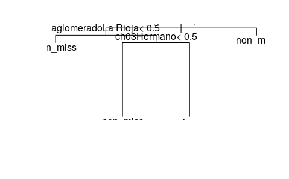

```r
plot(cart_tune$finalModel)
text(cart_tune$finalModel, pretty=1)
```

O de forma bonita:

```r
library(rpart.plot)
```

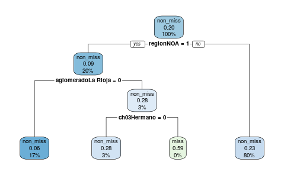

```r
rpart.plot(cart_tune$finalModel)
```

Testeemos la performance de este árbol:

```r
table(predict(cart_tune, df_train) , df_train$imp_inglab1)
```

```
           non_miss  miss
  non_miss    19397  4979
  miss            9    13
```

¿Qué conclusión pueden sacar al respecto?

Entrenen, ahora, un segundo árbol pero más complejo: `maxdepth=10`.

```r
cart_tune <- train(imp_inglab1 ~ . ,
                 data = df_train,
                 method = "rpart2",
                 trControl = fitControl,
                 tuneGrid = data.frame(maxdepth=10),
                 control = rpart.control(cp=0.0001)
)
```

[figure not shown]

```r
rpart.plot(cart_tune$finalModel)
```

```r
table(predict(cart_tune, df_train) , df_train$imp_inglab1)
```

```
           non_miss  miss
  non_miss    18836  3830
  miss          570  1162
```

Hasta aquí estuvimos haciendo trampa. Vamos a ahora a tunear el parámetro de profundidad de forma correcta.

### Seteando la partición para evaluar

Primero, fijamos la semilla aleatoria (para asegurarnos la posibilidad de replicabilidad)

```r
set.seed(789)
```

```r
cv_index <- createFolds(y = train$imp_inglab1,
                        k=5,
                        list=TRUE,
                        returnTrain=TRUE)
```

Finalmente, especificamos el diseño de remuestreo mediante la función `trainControl`:

```r
fitControl <- trainControl(
        index=cv_index,
        method="cv",
        number=5
        )
```

```r
grid <- expand.grid(maxdepth=c(1, 2, 4, 8, 10, 15, 20))
```

Y volvemos a entrenar el modelo:

```r
cart_tune
```

```
CART

19519 samples
   25 predictor
    2 classes: 'non_miss', 'miss'

No pre-processing
Resampling: Cross-Validated (5 fold)
Summary of sample sizes: 15615, 15615, 15616, 15615, 15615
Resampling results across tuning parameters:

  maxdepth  Accuracy   Kappa
   1        0.7986581  0.1090253
   2        0.7986581  0.1090253
   4        0.7986581  0.1090253
   8        0.7997339  0.1261417
  10        0.7997851  0.1290888
  15        0.8011171  0.1513197
  20        0.7707363  0.2210235

Accuracy was used to select the optimal model using
 the largest value.
The final value used for the model was maxdepth = 15.
```

## Seleccionando el mejor modelo

Una vez finalizado el proceso de tunning de los hiperparámetros, podemos proceder a elegir cuál es el mejor modelo y entrenarlo sobre todo el dataset. Podemos ver que el mejor es un árbol que parece demasiado complejo `maxdepth=15`, por ello, vamos a elegir uno un poco más interpreable

```r
cart_final
```

```
CART

19519 samples
   25 predictor
    2 classes: 'non_miss', 'miss'

No pre-processing
Resampling: Bootstrapped (25 reps)
Summary of sample sizes: 19519, 19519, 19519, 19519, 19519, 19519, ...
Resampling results:

  Accuracy   Kappa
  0.7945336  0.1356593

Tuning parameter 'maxdepth' was held constant at
 a value of 6
```

Podemos visualizarlo:

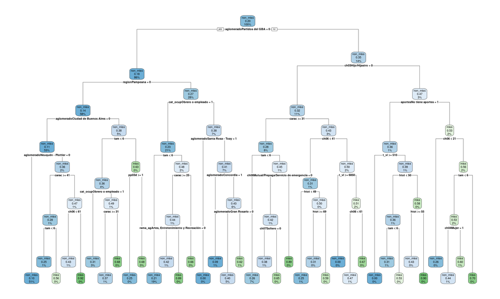

```r
rpart.plot(cart_final$finalModel)
```

Y generamos las predicciones finales:

```r
y_preds
```

[output not shown]

[output cut: 187 more lines]

Generamos nuestra matriz de confusión:

```r
confusionMatrix(y_preds, test$imp_inglab1)
```

```
Confusion Matrix and Statistics

          Reference
Prediction non_miss miss
  non_miss     3758  895
  miss          123  103

               Accuracy : 0.7914
                 95% CI : (0.7797, 0.8027)
    No Information Rate : 0.7954
    P-Value [Acc > NIR] : 0.7671

                  Kappa : 0.1003

 Mcnemar's Test P-Value : <2e-16

            Sensitivity : 0.9683
            Specificity : 0.1032
         Pos Pred Value : 0.8077
         Neg Pred Value : 0.4558
             Prevalence : 0.7954
         Detection Rate : 0.7702
   Detection Prevalence : 0.9537
      Balanced Accuracy : 0.5358

       'Positive' Class : non_miss
```

¿Qué se puede decir del árbol de decisión? ¿Cómo funciona?